# **Caso Prático 1 - Saúde Psicológica e Bem-estar**

Elaborado por:** Filipe Rego - 111533, Matilde Costa - 110995, Leonor Laborinho - 111287, Lúcia Yang - 111023, Tomás Monge - 98574

Abril de 2022

# **Introdução**

Neste relatório procede-se à analise de dados de um estudo sobre a saúde psicológica e bem-estar de crianças e adolescentes em idade escolar em diferentes regiões do norte de Portugal. Estes dados são provenientes de um questionário realizado a 996 indivíduos entre 11 e 20 anos. Com esta breve introdução, procede-se a montagem de gráficos e tabelas de modo a análisar, refletir e comparar os resultados obtidos. Em algumas tabelas e gráficos é possível observar o valor “99” que simboliza as não respostas.

# **Horas de sono**

Como se visualiza no gráfico, pode-se concluir que a maioria dos alunos dorme entre 7 a 9 horas.

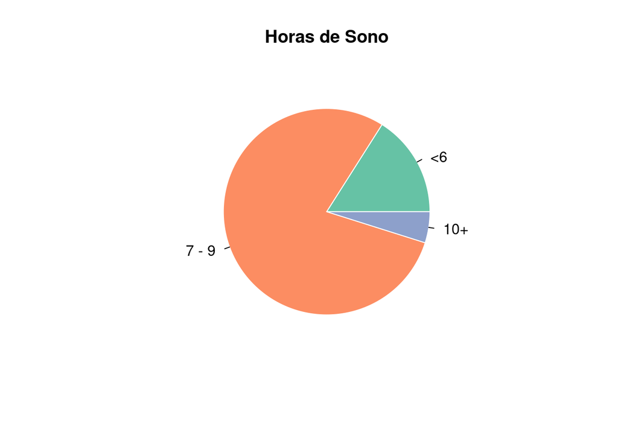

Pie Chart - Distribuição dos inquiridos por Horas de sono

# **Satisfação dos estudantes**

A partir deste gráfico analisamos que a mediana é de 7, que 75% dos alunos medem a sua satisfação com um nível inferior a 8 e 25% dos alunos autoavalia-se com um nível inferior a 6.

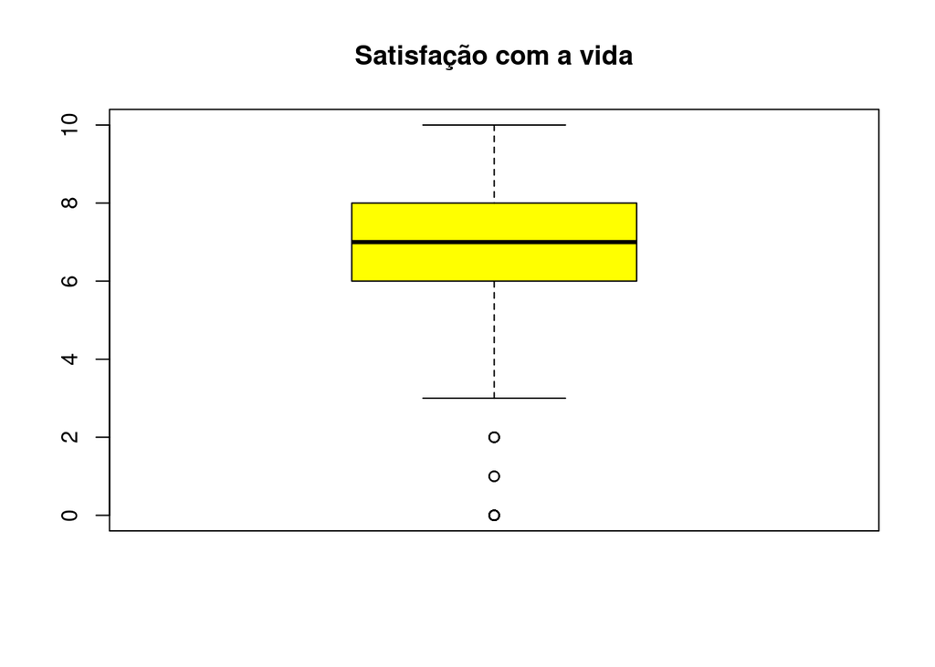

Boxplot - Distribuição dos estudantes pela sua satisfação com a vida

# **Género**

Ao visualizar o gráfico, percebe-se que a maioria do alunos que responderam ao inquérito identificam-se com o género feminino ou masculino, com uma ligeira diferença entre estes valores.

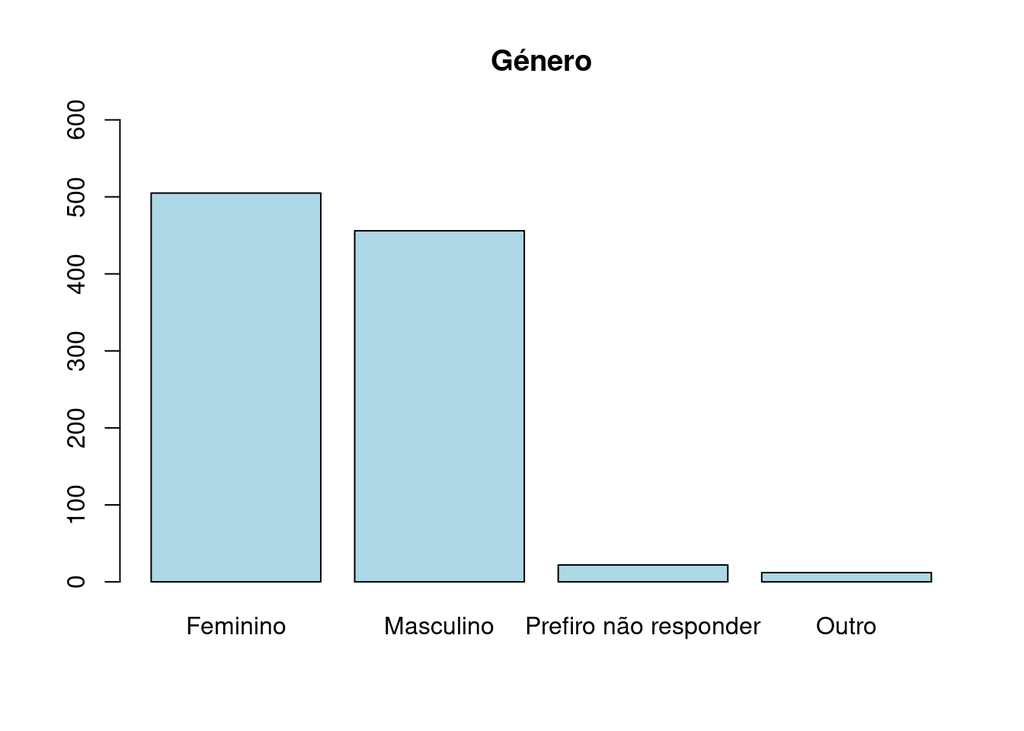

Barplot 1 - Distribuição dos alunos por gênero

# **Distrito**

Ao visualizar o gráfico seguinte, conclui-se que uma grande parte dos alunos questionados localizam-se em Braga e Porto.

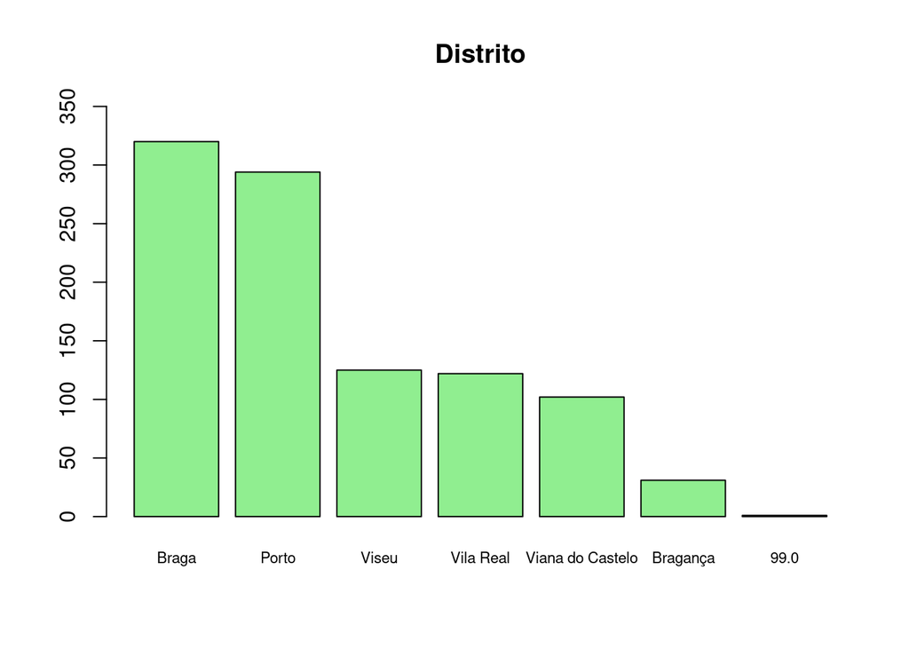

Barplot 2 - Distribuição dos alunos por distrito

# **Nível escolar do Encarregado de Educação**

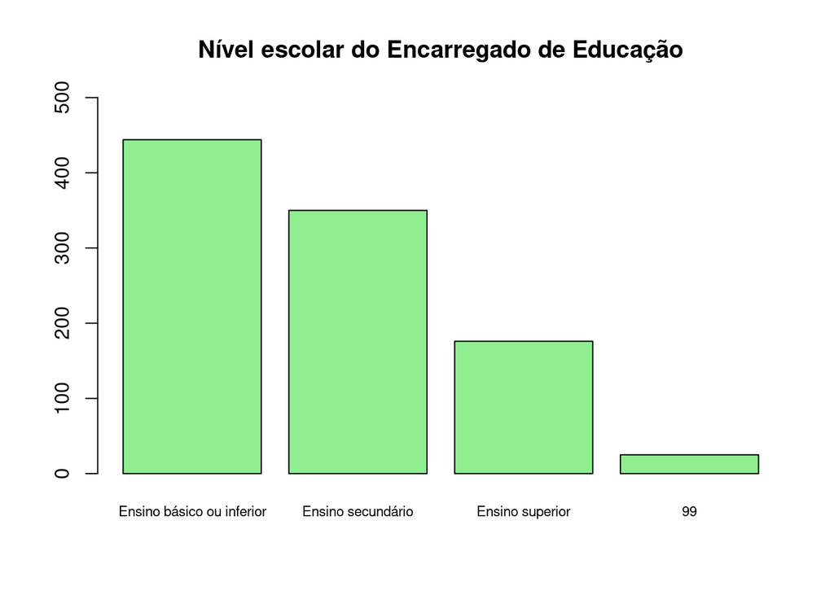

Barplot 3 - Distribuição dos alunos por nível escolar do encarregado de educação

# **Dificuldade em tomar iniciativa**

Os alunos autoavaliam a sua dificuldade em tomar iniciativa e conclui-se que a maioria tem sim uma dificuldade significativamente grande.

| Dificuldade em tomar iniciativa | N |
| --- | --- |
| Não se aplica a mim | 34 |
| Aplica-se algumas vezes | 65 |
| Aplica-se muitas vezes | 412 |
| Aplica-se muita parte do meu tempo | 165 |

Tabela 5 - Frequência absoluta

# **Sensações negativas variadas**

Nesta tabela observam-se as várias perguntas efetuadas e as respostas dos alunos, sendo possível verificar as dificuldades a níveis mentais e psicológicos que os alunos enfrentam no seu dia-a-dia.

| Legenda | Dificuldade em tomar iniciativa | Expectativa de Futuro | Depressão | Pouco entusiasmo | Valor pessoal | Pensamentos suicidas |
| --- | --- | --- | --- | --- | --- | --- |
| Não se aplicou a mim | 34 | 35 | 43 | 43 | 38 | 36 |
| Aplicou-se algumas vezes | 65 | 78 | 62 | 38 | 84 | 49 |
| Aplicou-se muitas vezes | 412 | 254 | 351 | 278 | 242 | 157 |
| Aplicou-se muita parte do meu tempo | 165 | 115 | 119 | 111 | 113 | 63 |

Tabela 6 - Frequência absoluta